# Data with Pandas

# Reading

See Chapter 5 of McKinney, W. (2012). Python for Data Analysis. O’Reilly.

Also, see the [online cookbook](http://pandas.pydata.org/pandas-docs/stable/tutorials.html).

# DataFrames

- The `pandas` module provides a powerful data-structure called a DataFrame.
- It is similar, but not identical to:
  - a table in a relational database,
  - an Excel spreadsheet,
  - a dataframe in R.
- They can be used to represent:
  - [Panel data](https://en.wikipedia.org/wiki/Panel_data)
  - [Time series](https://en.wikipedia.org/wiki/Time_series) data
  - [Relational data](https://en.wikipedia.org/wiki/Relational_model)
- DataFrames can be read and written to/from:
  - financial web sites
  - database queries
  - database tables
  - CSV files
  - json files
- Beware that DataFrames are memory resident.
  - If you read a large amount of data your PC might crash.
  - With big data, typically you would read a subset or summary of the data via e.g. a *select* statement.

# Importing Pandas

- The Pandas module is usually imported with the alias `pd`.

```python
import pandas as pd
```

# Pandas is Object-Oriented

- Pandas is object-oriented.
- We create data frames by constructing instances of different classes.
- The two most important classes are:
  - `DataFrame`
  - `Series`
- Pandas follows the Java convention of starting the name of classes with an upper-case letter, whereas instances are all lower-case.

# Data Types

- Both of these objects are collections of values.
- They are *ordered* and *mutable* collections.
- Pandas uses the [numpy scalar types](http://docs.scipy.org/doc/numpy/user/basics.types.html).

# Series

- A Series contains a one-dimensional array of data, *and* an associated sequence of labels called the *index*.
- The index can contain numeric, string, or date/time values.
- When the index is a time value, the series is a [time series](https://en.wikipedia.org/wiki/Time_series).
- The index must be the same length as the data.
- If no index is supplied it is automatically generated as `range(len(data))`.

# Creating a Series from an Array

```python
import numpy as np
data = np.random.randn(5)
data
```

```
array([ 0.82928331,  0.7993747 ,  0.22807259,  1.28923594, -0.60291671])
```

```python
my_series = pd.Series(data, index=['a', 'b', 'c', 'd', 'e'])
my_series
```

```
a    0.829283
b    0.799375
c    0.228073
d    1.289236
e   -0.602917
dtype: float64
```

# Plotting a Series

- We can plot a series by invoking the `plot()` method on an instance of a `Series` object.
- The $x$-axis will automatically be labelled with the Series index.

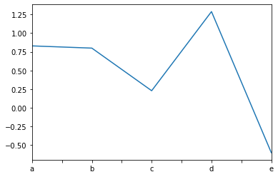

```python
my_series.plot()
```

# Creating a Series with Automatic Index

- In the following example the index is created automatically.

```python
pd.Series(data)
```

[output not shown]

# Creating a Series from a `dict`

```python
d = {'a' : 0., 'b' : 1., 'c' : 2.}
my_series = pd.Series(d)
my_series
```

```
a    0.0
b    1.0
c    2.0
dtype: float64
```

# Indexing a Series with `[]`

- Series can be accessed using the same syntax as arrays and dicts.
- We use the labels in the index to access each element.

```python
my_series['b']
```

```
1.0
```

- We can also use the label like an attribute:

```python
my_series.b
```

```
1.0
```

- We can specify a range of labels to obtain a slice:

```python
my_series[['b', 'c']]
```

```
b    1.0
c    2.0
dtype: float64
```

# Arithmetic and Vectorised Functions

- `numpy` vectorisation works for series objects too.
- Functions such as *cumsum* and *cumprod* are implemented for Series as [methods](https://pandas.pydata.org/pandas-docs/stable/reference/api/pandas.Series.html).

```python
d = {'a' : 0., 'b' : 1., 'c' : 2.}
squared_values = pd.Series(d) ** 2
squared_values
```

```
a    0.0
b    1.0
c    4.0
dtype: float64
```

```python
x = pd.Series({'a' : 0., 'b' : 1., 'c' : 2.})
y = pd.Series({'a' : 3., 'b' : 4., 'c' : 5.})
x + y
```

```
a    3.0
b    5.0
c    7.0
dtype: float64
```

# Time Series

```python
dates = pd.date_range('1/1/2000', periods=5)
dates
```

```
DatetimeIndex(['2000-01-01', '2000-01-02', '2000-01-03', '2000-01-04',
               '2000-01-05'],
              dtype='datetime64[ns]', freq='D')
```

```python
time_series = pd.Series(data, index=dates)
time_series
```

[output not shown]

[figure not shown]

```python
ax = time_series.plot()
```

# Missing Values

- Pandas uses `nan` to represent missing data.
- So `nan` is used to represent missing, invalid or unknown data values.
- It is important to note that this only convention only applies within pandas.
  - Other frameworks have very different semantics for these values.

# DataFrame

- A DataFrame has multiple columns, each of which can hold a *different* type of value.
- Like a Series, it has an index which provides a label for each and every row.
- DataFrames can be constructed from:
  - dict of arrays,
  - dict of lists,
  - dict of dict,
  - dict of Series,
  - 2-dimensional array,
  - a single Series,
  - another DataFrame.

# Creating a Dict of Series

```python
series_dict = {
        'x' :
            pd.Series([1., 2., 3.], index=['a', 'b', 'c']),
        'y' :
            pd.Series([4., 5., 6., 7.], index=['a', 'b', 'c', 'd']),
        'z' :
            pd.Series([0.1, 0.2, 0.3, 0.4], index=['a', 'b', 'c', 'd'])
}

series_dict
```

```
{'x': a    1.0
 b    2.0
 c    3.0
 dtype: float64, 'y': a    4.0
 b    5.0
 c    6.0
 d    7.0
 dtype: float64, 'z': a    0.1
 b    0.2
 c    0.3
 d    0.4
 dtype: float64}
```

# Converting the Dict to a DataFrame

```python
df = pd.DataFrame(series_dict)
df
```

|  | x | y | z |
| --- | --- | --- | --- |
| a | 1.0 | 4.0 | 0.1 |
| b | 2.0 | 5.0 | 0.2 |
| c | 3.0 | 6.0 | 0.3 |
| d | NaN | 7.0 | 0.4 |

# Plotting DataFrames

- When plotting a DataFrame, each column is plotted as its own series on the same graph.
- The column names are used to label each series.
- The row names (index) is used to label the x-axis.

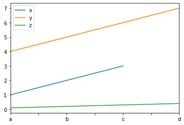

```python
ax = df.plot()
```

# Indexing

- The outer dimension is the column index.
- When we retrieve a single column, the result is a Series

```python
df['x']
```

```
a    1.0
b    2.0
c    3.0
d    NaN
Name: x, dtype: float64
```

```python
df['x']['b']
```

```
2.0
```

```python
df.x.b
```

```
2.0
```

# Projections

- DataFrames and Series can be sliced.
- When we slice columns we call this a *projection*, because it is analogous to specifying a subset of attributes in a relational query, e.g. `SELECT x FROM table`.
- If we project a single column the result is a Series:

```python
slice = df['x'][['b', 'c']]
slice
```

```
b    2.0
c    3.0
Name: x, dtype: float64
```

```python
type(slice)
```

```
pandas.core.series.Series
```

# Projecting Multiple Columns

- When we include multiple columns in the projection the result is a DataFrame.

```python
slice = df[['x', 'y']]
slice
```

|  | x | y |
| --- | --- | --- |
| a | 1.0 | 4.0 |
| b | 2.0 | 5.0 |
| c | 3.0 | 6.0 |
| d | NaN | 7.0 |

```python
type(slice)
```

```
pandas.core.frame.DataFrame
```

# Slicing Using .loc

- The slicing operator ":" does not work well with DataFrames and indexing using this last method.
- This is supported however through using `.loc`.
- Syntax: `df.loc[row_indexer,column_indexer]`.

```python
df.loc[:,['x','y']]
```

|  | x | y |
| --- | --- | --- |
| a | 1.0 | 4.0 |
| b | 2.0 | 5.0 |
| c | 3.0 | 6.0 |
| d | NaN | 7.0 |

```python
df.loc['b':'d',['x','y']]
```

|  | x | y |
| --- | --- | --- |
| b | 2.0 | 5.0 |
| c | 3.0 | 6.0 |
| d | NaN | 7.0 |

# Slicing Using `.iloc`

If we use `.iloc` instead, we can index using the standard numbering $0, 1, 2, \ldots$ instead of using the Pandas custom row and column indices.

```python
df.iloc[1:,0:2]
```

|  | x | y |
| --- | --- | --- |
| b | 2.0 | 5.0 |
| c | 3.0 | 6.0 |
| d | NaN | 7.0 |

# Logical Indexing

- We can use logical indexing to retrieve a subset of the data.

```python
df[df['x'] >= 2]
```

|  | x | y | z |
| --- | --- | --- | --- |
| b | 2.0 | 5.0 | 0.2 |
| c | 3.0 | 6.0 | 0.3 |

# Vectorisation

- Vectorised functions and operators work just as with Series objects:

```python
df['x'] + df['y']
```

```
a    5.0
b    7.0
c    9.0
d    NaN
dtype: float64
```

```python
df ** 2
```

|  | x | y | z |
| --- | --- | --- | --- |
| a | 1.0 | 16.0 | 0.01 |
| b | 4.0 | 25.0 | 0.04 |
| c | 9.0 | 36.0 | 0.09 |
| d | NaN | 49.0 | 0.16 |

# Descriptive Statistics

- To quickly obtain descriptive statistics on numerical values use the `describe` method.

```python
df.describe()
```

|  | x | y | z |
| --- | --- | --- | --- |
| count | 3.0 | 4.000000 | 4.000000 |
| mean | 2.0 | 5.500000 | 0.250000 |
| std | 1.0 | 1.290994 | 0.129099 |
| min | 1.0 | 4.000000 | 0.100000 |
| 25% | 1.5 | 4.750000 | 0.175000 |
| 50% | 2.0 | 5.500000 | 0.250000 |
| 75% | 2.5 | 6.250000 | 0.325000 |
| max | 3.0 | 7.000000 | 0.400000 |

# Accessing a Single Statistic

- The result is itself a DataFrame, so we can index a particular statistic like so:

```python
df.describe()['x']['mean']
```

```
2.0
```

# Accessing the Row and Column Labels

- The row labels (index) and column labels can be accessed:

```python
df.index
```

```
Index(['a', 'b', 'c', 'd'], dtype='object')
```

```python
df.columns
```

```
Index(['x', 'y', 'z'], dtype='object')
```

# Financial Data

- Pandas was originally developed to analyse financial data.
- We can download tabulated data in a portable format called [Comma Separated Values (CSV)](https://www.loc.gov/preservation/digital/formats/fdd/fdd000323.shtml).

```python
import pandas as pd
googl = pd.read_csv('C:/GOOG.csv')
```

```python
googl.head()
```

|  | Date | Open | High | Low | Close | Adj Close | Volume |
| --- | --- | --- | --- | --- | --- | --- | --- |
| 0 | 2013-11-29 | 527.648132 | 529.863770 | 526.301941 | 526.371460 | 526.371460 | 2401000 |
| 1 | 2013-12-02 | 528.318787 | 529.729614 | 521.984985 | 523.832947 | 523.832947 | 2764200 |
| 2 | 2013-12-03 | 522.079407 | 528.283997 | 521.120605 | 523.226929 | 523.226929 | 3373900 |
| 3 | 2013-12-04 | 522.288025 | 528.552307 | 521.607422 | 525.671021 | 525.671021 | 2398600 |
| 4 | 2013-12-05 | 525.184204 | 526.406250 | 522.148926 | 525.253723 | 525.253723 | 2282000 |

# Converting to `datetime` Values

- So far, the `Date` attribute is of type string.

```python
googl.Date[0]
```

```
'2013-11-29'
```

```python
type(googl.Date[0])
```

```
str
```

- In order to work with time series data, we need to construct an index containing time values.
- Time values are of type `datetime` or `Timestamp`.
- We can use the function `to_datetime()` to convert strings to time values.

```python
pd.to_datetime(googl['Date']).head()
```

[output not shown]

# Setting the Index

- Now we need to set the index of the DataFrame so that it contains the sequence of dates.

```python
googl.set_index(pd.to_datetime(googl['Date']), inplace=True)
googl.index[0]
```

```
Timestamp('2013-11-29 00:00:00')
```

```python
type(googl.index[0])
```

```
pandas._libs.tslibs.timestamps.Timestamp
```

# Plotting Series

- We can plot a series in a DataFrame by invoking its `plot()` method.
- Here we plot a time series of the daily traded volume:

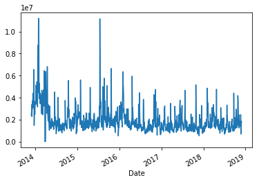

```python
ax = googl['Volume'].plot()
```

## Adjusted Closing Prices as a Time Series

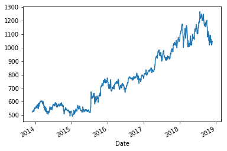

```python
googl['Adj Close'].plot()
```

# Slicing Series using Date/Time-Stamps

- We can slice a time series by specifying a range of dates or times.
- Date and time stamps are specified strings representing dates in the required format.

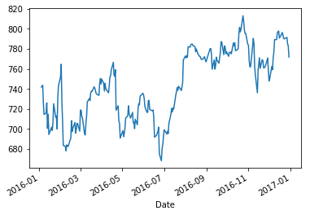

```python
googl['Adj Close']['1-1-2016':'1-1-2017'].plot()
```

# Resampling

- We can *resample* to obtain e.g. weekly or monthly prices.
- In the example below the `'W'` denotes weekly.
- See [the documentation](http://pandas.pydata.org/pandas-docs/stable/timeseries.html#offset-aliases) for other frequencies.
- We group data into weeks, and then take the last value in each week.
- For details of other ways to resample the data, see [the documentation](http://pandas.pydata.org/pandas-docs/stable/generated/pandas.DataFrame.resample.html).

```python
weekly_prices = googl['Adj Close'].resample('W').last()
weekly_prices.head()
```

```
Date
2013-12-01    526.371460
2013-12-08    531.478271
2013-12-15    526.967590
2013-12-22    546.753906
2013-12-29    555.586426
Freq: W-SUN, Name: Adj Close, dtype: float64
```

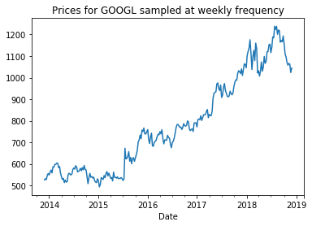

```python
import matplotlib as plt
weekly_prices.plot()
plt.title('Prices for GOOGL sampled at weekly frequency')
plt.show()
```

# Converting Prices to Log-Returns

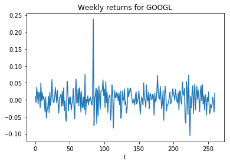

```python
weekly_rets = np.diff(np.log(weekly_prices))
plt.plot(weekly_rets)
plt.xlabel('t')
plt.title('Weekly returns for GOOGL')
plt.show()
```

# Converting the Returns to a Series

- Notice that in the above plot the time axis is missing the dates.
- This is because the `np.diff()` function returns an array instead of a DataFrame.

```python
type(weekly_rets)
```

```
numpy.ndarray
```

- We can convert it to a Series, thus:

```python
weekly_rets_series = pd.Series(weekly_rets, index=weekly_prices.index[1:])
weekly_rets_series.head()
```

```
Date
2013-12-08    0.009655
2013-12-15   -0.008523
2013-12-22    0.036860
2013-12-29    0.016025
2014-01-05   -0.012054
Freq: W-SUN, dtype: float64
```

Now when we plot the series we will obtain the correct time axis:

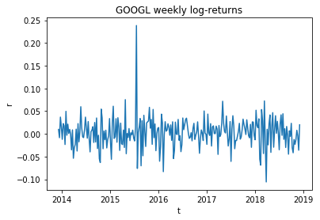

```python
plt.plot(weekly_rets_series)
plt.title('GOOGL weekly log-returns'); plt.xlabel('t'); plt.ylabel('r')
plt.show()
```

# Plotting a Return Histogram

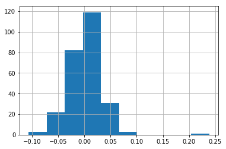

```python
weekly_rets_series.hist()
plt.show()
```

```python
weekly_rets_series.describe()
```

```
count    261.000000
mean       0.002625
std        0.032555
min       -0.105935
25%       -0.014452
50%        0.003282
75%        0.022161
max        0.238519
dtype: float64
```

# Importing Financial Data using Pandas Datareader

Pandas Datareader is a Python module that allows direct downloading of historical financial data into a Pandas DataFrame.

- Started as part of Pandas,
- Now a separate module,
- [Many supported data sources](https://pandas-datareader.readthedocs.io/en/latest/remote_data.html) (but some require a key).

```python
from pandas_datareader import data
googlframe = data.DataReader("GOOGL","stooq", "2013-11-29", "2022-11-29")
googlframe.head()
```

| Date | Open | High | Low | Close | Volume |
| --- | --- | --- | --- | --- | --- |
| 2022-11-29 | 95.7300 | 96.12 | 94.11 | 95.19 | 20061720 |
| 2022-11-28 | 97.0363 | 97.58 | 95.61 | 96.05 | 26252433 |
| 2022-11-25 | 98.2400 | 98.64 | 97.40 | 97.46 | 9701441 |
| 2022-11-23 | 97.0900 | 98.76 | 97.09 | 98.46 | 18868092 |
| 2022-11-22 | 95.9500 | 97.22 | 94.05 | 97.05 | 23438480 |

```python
djframe = data.DataReader("^DJI","stooq", "2018-01-01", "2019-11-11")
djframe
```

[output not shown]

# Relying on External APIs

Be careful relying on external sources.

- Yahoo Finance provided one of the more popular APIs but suddenly [closed down for a while](https://www.youtube.com/watch?v=lojDfxsARLo).
- Google Finance API was also shut down last year without notice.
- Good idea to save your data once you have it.

```python
googlframe2 = data.DataReader("GOOGL","google", "2013-11-29", "2019-11-29")
```

```
---------------------------------------------------------------------------
NotImplementedError                       Traceback (most recent call last)
<ipython-input-14-60d7f932e8bf> in <module>
----> 1 googlframe2 = data.DataReader("GOOGL","google", "2013-11-29", "2019-11-29")

C:\ProgramData\Anaconda3\lib\site-packages\pandas\util\_decorators.py in wrapper(*args, **kwargs)
    206                 else:
    207                     kwargs[new_arg_name] = new_arg_value
--> 208             return func(*args, **kwargs)
    209
    210         return wrapper

C:\ProgramData\Anaconda3\lib\site-packages\pandas_datareader\data.py in DataReader(name, data_source, start, end, retry_count, pause, session, api_key)
    374     if data_source not in expected_source:
    375         msg = "data_source=%r is not implemented" % data_source
--> 376         raise NotImplementedError(msg)
    377
    378     if data_source == "yahoo":

NotImplementedError: data_source='google' is not implemented
```

# Using Yahoo Finance with Pandas Datareader

In 2022, Yahoo Finance stopped working as it used to, with Pandas Datareader.

- You now need to import the module `yfinance` and call `pdr_override`.
- After that, using Pandas Datareader, you'll need to make use of `get_data_yahoo`.

```python
import pandas
from pandas_datareader import data
import yfinance as yfin

yfin.pdr_override()

googlframe = data.get_data_yahoo('GOOGL', start='2022-10-24', end='2022-12-23')

print(googlframe.head())
```

```
[*********************100%%**********************]  1 of 1 completed
                  Open        High         Low       Close   Adj Close  \
Date
2022-10-24  101.800003  102.750000   99.980003  102.519997  102.519997
2022-10-25  102.900002  104.820000  102.720001  104.480003  104.480003
2022-10-26   96.430000   98.309998   94.690002   94.930000   94.930000
2022-10-27   94.519997   95.430000   91.800003   92.220001   92.220001
2022-10-28   92.269997   96.550003   92.129997   96.290001   96.290001

              Volume
Date
2022-10-24  27176400
2022-10-25  40611400
2022-10-26  88114100
2022-10-27  60710900
2022-10-28  43697300
```

- Install Pandas Datareader using conda install `pandas-datareader`.
- Install yfinance using the command conda `install -c conda-forge yfinance`.

# Storing your Data

Storing a data frame as a csv-file is easy.

- Just use the to_csv($\cdot$)-method.

```python
googlframe.to_csv("C:/GOOGL.csv")
```